# AOOI3_Aula08_DiagramasClassesDominio-BD

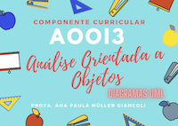

Instituto Federal de São Paulo (IFSP)  
[Campus Bragança Paulista/SP](https://bra.ifsp.edu.br)  
**Análise e Desenvolvimento de Sistemas (ADS)**  
**3o. módulo**  
**Profa. Ana Paula Müller Giancoli**  
paulagiancoli@ifsp.edu.br

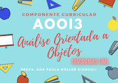

## AULA 08 - DIAGRAMAS DE CLASSES DE DOMÍNIO E BD

### Agenda

- Diagramas de Classes de Domínio e BD
- Perguntas

### 1. Implementações de Associações

| Associações Simples são: |
| --- |
| 1-para-1 |
| 0..1-para-1 |
| 1-para-muitos |
| muitos-para-muitos |

### 1.2. Associações 1-para-1

**PROPOSTA: EMBUTIR A CHAVE ESTRANGEIRA EM QUALQUER UMA DAS CLASSES**.  
Se a multiplicidade mínima 0 (do alvo), a chave estrangeira poderá ser nula (NULL).

**1-para-1**

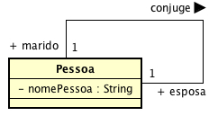

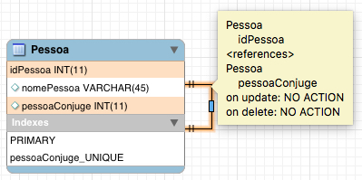

### 1.3. Associações 0..1-para-1

**PROPOSTA: EMBUTIR A CHAVE ESTRANGEIRA NA CLASSE COM MULTIPLICIDADE 0..1**.  
A chave estrangeira não poderá ser nula (NOT NULL).

**0..1-para-1**

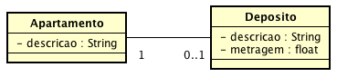

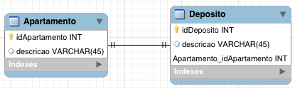

### 1.4. Associações 1-para-muitos

**PROPOSTA: EMBUTIR A CHAVE ESTRANGEIRA NA CLASSE COM MULTIPLICIDADE MUITOS**.  
Se a multiplicidade 1 (do alvo) puder ser 0 ou 1, a chave estrangeira poderá ser nula (NULL).

**1-para-muitos**

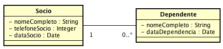

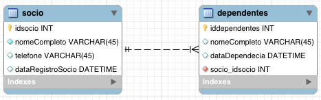

### 1.5. Associações muitos-para-muitos

**PROPOSTA: A ASSOCIAÇÃO É MAPEADA PARA UMA TABELA DISTINTA**.  
A chave primária da tabela de associação é uma combinação das chaves estrangeiras.

**muitos-para-muitos**

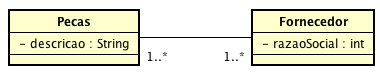

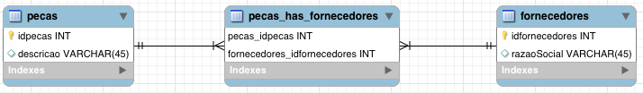

### 2. Implementações de Associações Avançadas

- Associações Avançadas são:
  - Associação qualificada.
  - Classe de Associação.
  - Associação Ordenada.
  - Associação Ternária.

### 2.1. Associação qualificada

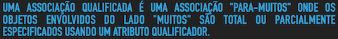

- Aumentam a precisão dos modelos.
- Um qualificador seleciona um ou mais dentre vários objetos-alvo, com efeito de reduzir a cardinalidade, às vezes até 1.
- Quando a cardinalidade final é 1, a associação qualificada especifica uma forma precisa de selecionar o objeto alvo a partir do objeto fonte.

**PROPOSTA: O MAPEAMENTO É IDÊNTICO PARA A ASSOCIAÇÃO QUALIFICADA E NÃO QUALIFICADA**.  
Uma chave estrangeira deve ser incluída na classe que não possui a qualificação.

**qualificada**

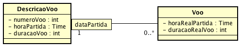

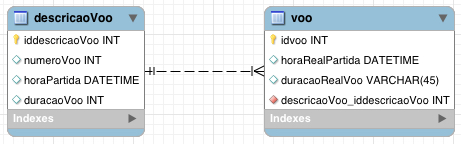

### 2.3. Classe de Associativas

**classes associativas**

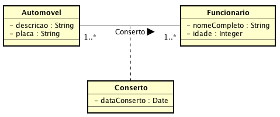

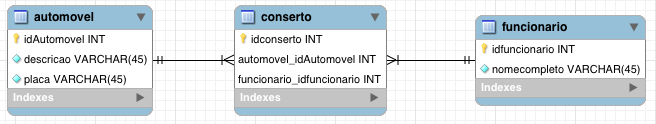

### 2.4. Associação Ordenada

- Ocorre quando as ligações entre objetos possuem uma ordem.
- **Exemplo**: janelas podem estar em uma ordem ao surgirem em uma tela.
- A tag UML {ordered} é usada na associação (ou {ordered by...}).
- **Proposta: Introduzir um número de sequencia como atributo**.

### 2.5. Associação Ternária

- Uma tabela distinta deve ser usada para representar a associação ternária.

### 2.6. Associação do tipo Agregações

- Agregações são associações e são implementadas como tal.

### 2.7. Herança Simples Generalização

### Herança Simples

- Normalmente, a herança é implementada com tabelas separadas para a superclasse e cada subclasse.
- Idealmente, um objeto tem a mesma chave primária na hierarquia inteira.
- A superclasse inclui um discriminador que indica qual a subclasse se aplica (não é mostrado no modelo de objetos).
- O código da aplicação deve implementar a restrição.

**herança simples**

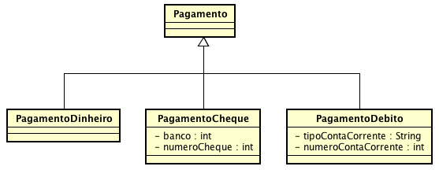

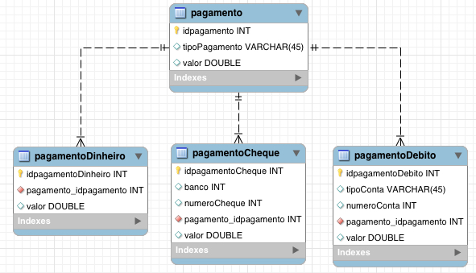

### Referências

- Esta aula foi elaborada a partir do conteúdo disponibilizado em cada um dos links indicados no próprio texto.
- GUEDES, G. T. A. UML 2 - **UMA ABORDAGEM PRÁTICA**. [S.L.]: NOVATEC, 2011.
- MEDEIROS, Ernani - **Desenvolvendo Software com UML 2.0 Definitivo** - Editora Pearson Makron Books.
- BOOCH, Grady; RUMBAUGH, James; JACOBSON, Ivar - **UML Guia do Usuário** - 2a. Edição - Editora Campus (Elsevier).

### Perguntas

- Esclareça suas eventuais dúvidas durante as aulas.
- Ou pelo *E-mail*: paulagiancoli@ifsp.edu.br.
- Ou acesse [Github Ana Giancoli](https://anagiancoli.github.io) e solicite atendimento para o componente curricular.
- Ou pelo *Fórum* do componente curricular.

*ADS - AOO - 3o. módulo*.  
Modelo e formato elaborado por profa. Ana Paula Müller Giancoli - BSD 2-Clause License. - Setembro.2020.